# EUR/SGD Zeitreihenanalyse in R

Dennis Prüß

19.11.2023

In diesem Projekt führe ich eine Zeitreihenanalyse des Wechselkurses zwischen dem Euro (EUR) und dem Singapur-Dollar (SGD) durch. Die Auswahl dieser Zeitreihe ist für mich besonders wichtig, da ich derzeit mein Auslandssemester in Singapur absolviere. Das Verständnis der Wechselkursentwicklung zwischen dem Euro und dem Singapur-Dollar ist relevant für meinen Alltag, insbesondere hinsichtlich finanzieller Entscheidungen und Budgetplanung. Ich verwende historische Preisdaten von Yahoo Finance, um Trends und saisonale Muster zu untersuchen und im Anschluss eine Prognose des zukünftigen Wechselkurses zu bilden.

Im Folgenden werde ich die erforderlichen Schritte für die Analyse durchgehen und einzelne Schritte kurz erklären. Ich gehe dabei nicht im Detail auf die Berechnungen und statistischen Modelle ein, sondern erkläre nur grob, warum ich bestimmte Funktionen verwende und interpretiere die Ergebnisse.

### Installation & Aktivierung notwendiger Packages

```r
# Packages installieren, falls noch nicht vorhanden
# install.packages("tseries")
# install.packages("forecast")
# install.packages("ggplot2")
```

```r
# Packages laden
library(tseries)
```

```r
library(forecast)
library(ggplot2)
```

## Datenvorbereitung

Im ersten Schritt werden die Daten eingelesen und so formatieren, dass sie in ein Zeitreihenobjekt umgewandelt werden und im Anschluss analysiert werden.

```r
# Alle Objekte aus dem Arbeitsspeicher löschen
rm(list = ls())

# Arbeitsverzeichnis setzen
setwd("/Users/dennispruss/Documents/02_Karriere/01_pruess_xyz/01_Projects/002_EURSGD Zeitreihenanalyse")

# Datensatz einlesen
sgd <- read.csv(file = "EURSGD_weekly.csv", header = TRUE, sep = ",", dec = ".")

# Irrelevante Spalten entfernen
sgd <- sgd[, -c(2, 3, 4, 6, 7)]

# Überprüfung, ob die Datei fehlende Werte enthält
anyNA(sgd)
```

```
## [1] FALSE
```

```r
# Daten für die Analyse bereit?
head(sgd)
```

```
##         Date  Close
## 1 2004-01-01 2.1432
## 2 2004-01-08 2.1548
## 3 2004-01-15 2.1473
## 4 2004-01-22 2.1106
## 5 2004-01-29 2.1244
## 6 2004-02-05 2.1385
```

```r
str(sgd)
```

```
## 'data.frame':    1039 obs. of  2 variables:
##  $ Date : chr  "2004-01-01" "2004-01-08" "2004-01-15" "2004-01-22" ...
##  $ Close: num  2.14 2.15 2.15 2.11 2.12 ...
```

```r
# Datum in geeignetes Format umwandeln
sgd$Date <- as.Date(sgd$Date, format="%Y-%m-%d")

# Konvertieren der Daten in ein Zeitreihenobjekt
sgd_ts <- ts(sgd$Close, start = c(2004, 1), frequency = 52)
```

## Identifikationsphase

In der Identifikationsphase wird die Zeitreihe auf Muster und Trends geprüft, um die Daten für ein passendes Model vorzubereiten. Die Zeitreihe muss auf Stationarität geprüft werden und gegebenenfalls differenziert werden.

#### Grafische Darstellung

Der erste Schritt ist die Visualisierung der Zeitreihe. Gewisse Muster und Trends können schon mit dem einfachen Auge erkannt werden und benötigen keine fortgeschrittenen statistischen Methoden.

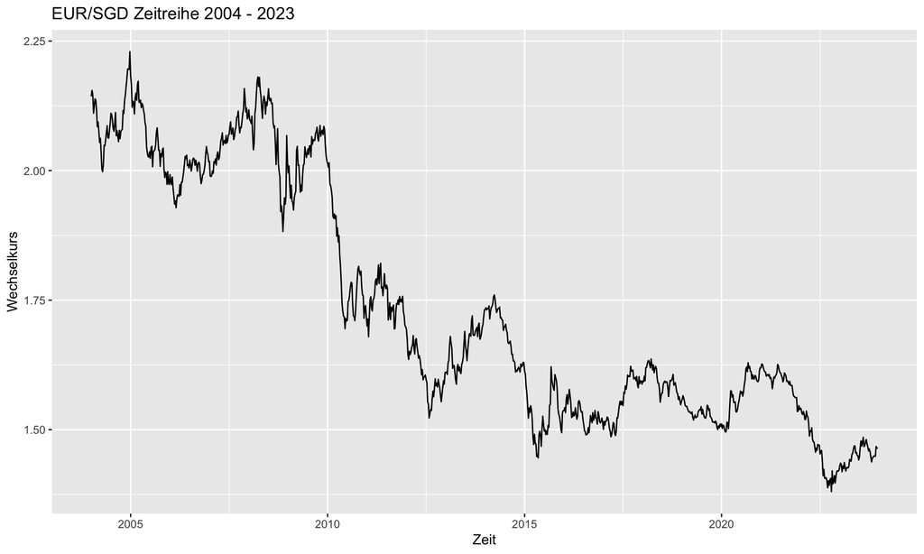

```r
# Plot erstellen
autoplot(sgd_ts) +
  ggtitle("EUR/SGD Zeitreihe 2004 - 2023") +
  xlab("Zeit") +
  ylab("Wechselkurs")
```

Die Grafik verdeutlicht deutlich einen Abwärtstrend, insbesondere starke Abwärtsbewegungen des Eurokurses zu Beginn des Jahres 2010. Diese drastische Abnahme des EUR/SGD-Kurses ist auf Schuldenprobleme einiger Länder in der Eurozone zurückzuführen. Die Auswirkungen der globalen Finanzkrise erwiesen sich für die Eurozone als schwerwiegender im Vergleich zu Singapur.

#### Dickey-Fuller-Test

Der Dickey-Fuller-Test ist ein Verfahren zur Überprüfung der Stationarität einer Zeitreihe. Einfacher ausgedrückt wird damit untersucht, ob die Zeitreihe über die Zeit konstant ist oder einen Trend (aufwärts/abwärts) aufweist. Falls ein Trend festgestellt wird, ist es notwendig, diesen zu entfernen, um die Stationarität zu gewährleisten.

```r
# Dickey-Fuller-Test anwenden
adf.test(sgd_ts)
```

```
##
##  Augmented Dickey-Fuller Test
##
## data:  sgd_ts
## Dickey-Fuller = -2.3152, Lag order = 10, p-value = 0.4449
## alternative hypothesis: stationary
```

Das Ergebnis des Tests deutet darauf hin, dass die Zeitreihe wahrscheinlich nicht stationär ist, da der p-Wert deutlich größer als 0,05 ist. Dies legt nahe, dass ein Trend in der Zeitreihe vorhanden ist. Diese Schlussfolgerung wird durch die zuvor durchgeführte Visualisierung im ersten Schritt zusätzlich bestätigt.

#### Differenzierung

Die Differenzierung hilft dabei, den Trend in der Zeitreihe zu entfernen und so eine Stationarität zu erreichen.

```r
# Differenzierung
sgd_ts_diff <- diff(sgd_ts)
```

Nun wird der Dickey-Fuller-Test erneut durchgeführt, um sicherzustellen, dass die Zeitreihe nun stationär ist.

```r
# Dickey-Fuller-Test erneut anwenden
adf.test(sgd_ts_diff)
```

```
##
##  Augmented Dickey-Fuller Test
##
## data:  sgd_ts_diff
## Dickey-Fuller = -10.066, Lag order = 10, p-value = 0.01
## alternative hypothesis: stationary
```

Das Ergebnis des Dickey-Fuller-Tests nach der Differenzierung zeigt einen niedrigen p-Wert von 0,01. Dies deutet darauf hin, dass die Zeitreihe nach der Differenzierung nun stationär ist. Jetzt können detailliertere Analysen nach Mustern und Trends durchgeführt werden, um ein besseres Verständnis der Daten zu gewinnen.

#### Korrelationsfunktionen

Mithilfe der `tsdisplay` Funktion wird die nun stationäre Zeitreihe erneut visualisiert. Zusätzlich werden die Autokorrelationsfunktion (ACF) und die Partielle Autokorrelationsfunktion (PACF) berechnet und dargestellt. Die ACF gibt Auskunft darüber, wie stark aufeinander folgende Werte in der Zeitreihe miteinander korrelieren. Die PACF untersucht ebenfalls die Korrelation, fokussiert sich jedoch auf die direkte (partielle) Korrelation zwischen dem aktuellen Wert und einem vergangenen, ohne die dazwischenliegenden Werte zu berücksichtigen.

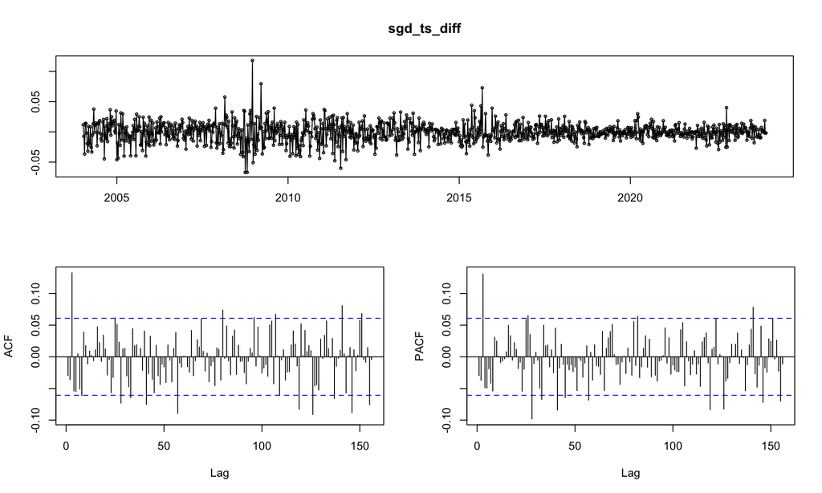

```r
# ACF und PACF berechnen
tsdisplay(sgd_ts_diff)
```

Die Grafik der Zeitreihe deutet darauf hin, dass sie stationär ist, was bereits durch den Dickey-Fuller-Test zuvor bestätigt wurde. Die ACF und PACF befinden sich überwiegend im 95% Intervall (blaue Schattierung), was darauf hindeutet, dass die Korrelationen auf Zufall basieren und nicht statistisch signifikant sind.

#### Trendanalyse und Saisonale Muster

Mittels der `decompose` Funktion zerlege ich die Zeitreihe in ihre Trend-, Saison- und Restkomponenten. Das Diagramm visualisiert diese Komponenten über die Zeit, was hilfreich ist, um potenzielle Trends oder saisonale Muster zu identifizieren. Diese Visualisierung ermöglicht es, spezifische saisonale Spitzen, wie sie in Währungsmärkten auftreten können, genauer zu erkennen und zu analysieren.

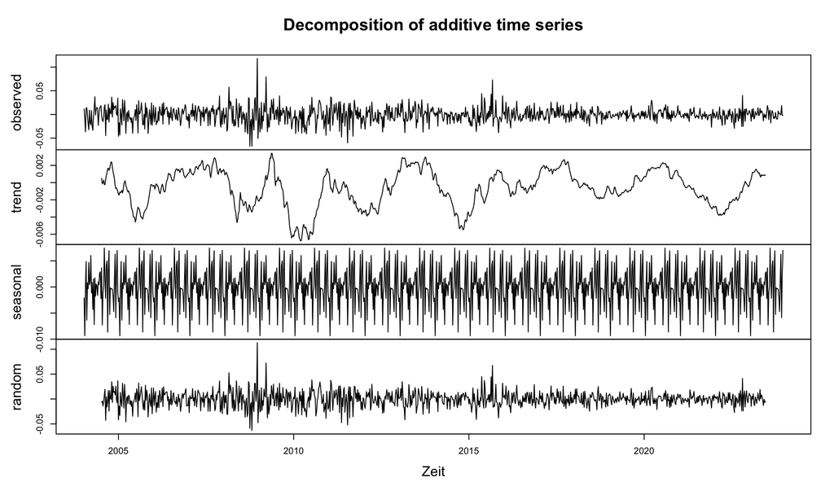

```r
# Erkennung von Trends
sgd_ts_dec<- decompose(sgd_ts_diff)
plot(sgd_ts_dec, xlab = "Zeit")
```

Die Grafiken deuten darauf hin, dass nach der Differenzierung kein eindeutiger Trend mehr vorhanden ist. Es sind keine klaren saisonalen Muster erkennbar. Die Zufallskomponente zeigt jedoch markante Ausschläge, insbesondere während der Finanzkrise von 2009 und der Eurokrise von 2015.

#### Saisonale Muster

Mithilfe der Funktion `ggseasonplot` lassen sich saisonale Muster in der Zeitreihe grafisch darstellen. Dadurch können regelmäßige Muster oder Schwankungen über das Jahr hinweg leicht erkannt werden.

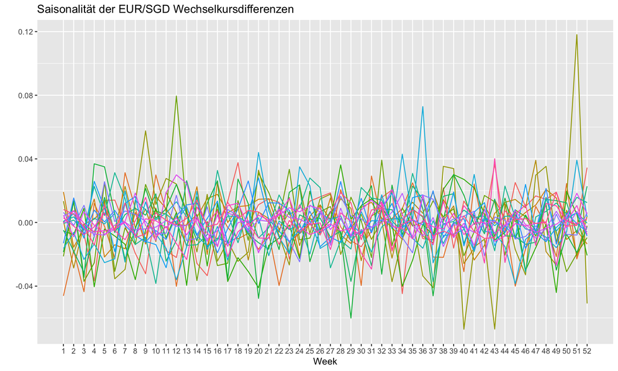

```r
# Erstellung Plot Saisonalität
ggseasonplot(sgd_ts_diff) +
  ggtitle("Saisonalität der EUR/SGD Wechselkursdifferenzen") +
  theme(legend.position = "none")
```

In der Visualisierung sind keine Auffälligkeiten zu erkennen, die auf saisonale Muster hindeuten. Dies stimmt mit der vorherigen Grafik aus der `decompose` Funktion überein. Die Wechselkursschwankungen variieren über das Jahr, ohne klare regelmäßige Muster.

## Schätzphase

In der Schätzphase wird ein Modell erstellt, dass die Zeitreihe optimal widerspiegelt. Das Ziel ist es, eine realistische Kursprognose für den Wechselkurs entwickeln. Ich verwende die Funktion `auto.arima`, die mithilfe eines Algorithmus die besten Parameter für das ARIMA-Modell ermittelt.

```r
# ARIMA Modell erstellen
arima_model <- auto.arima(sgd_ts,
                    d = 1,
                    D = 1,
                    stepwise = FALSE,
                    approximation = FALSE,
                    trace = TRUE)
```

```r
# Übersicht der Parameter
summary(arima_model)
```

```
## Series: sgd_ts
## ARIMA(0,1,3)(2,1,0)[52]
##
## Coefficients:
##           ma1      ma2     ma3     sar1     sar2
##       -0.0165  -0.0011  0.1355  -0.6618  -0.2891
## s.e.   0.0317   0.0330  0.0329   0.0311   0.0312
##
## sigma^2 = 0.0003473:  log likelihood = 2518.16
## AIC=-5024.31   AICc=-5024.23   BIC=-4994.95
##
## Training set error measures:
##                         ME       RMSE        MAE          MPE      MAPE
## Training set -6.949468e-05 0.01810807 0.01331365 -0.005379735 0.7682325
##                   MASE         ACF1
## Training set 0.1486777 -0.007762472
```

Die ARIMA-Modellparameter zeigen niedrige Varianz und gute Fehlermaße, was auf eine wahrscheinlich gute Prognosefähigkeit hindeutet. Die anderen Parameter unterstützen diese Aussage, wobei ich hier nicht näher darauf eingehe. Insgesamt lässt dies darauf schließen, dass das ARIMA-Modell eine solide Basis für zukünftige Wechselkursprognosen bietet.

## Diagnosephase

In der Diagnosephase erfolgt eine vertiefte Prüfung des erstellten Modells, um sicherzustellen, dass es für Prognosen geeignet ist. Die Residuenanalyse ermöglicht eine Untersuchung der Unterschiede zwischen den vorhergesagten Daten des Modells und den tatsächlichen Werten. Ein gutes Modell zeigt gleichmäßig verteilte Residuen.

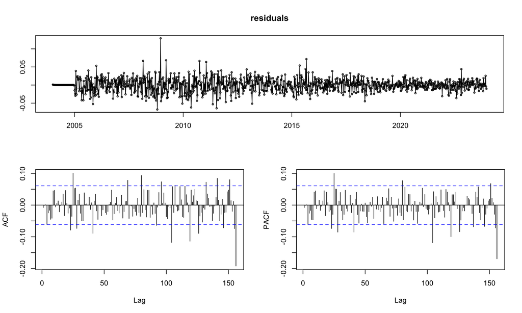

```r
# Residuen analysieren
residuals <- resid(arima_model)
tsdisplay(residuals)
```

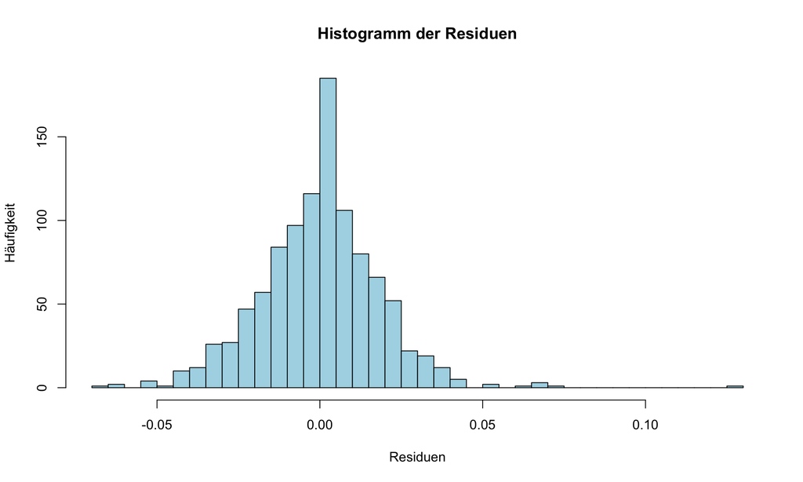

```r
# Histogramm der Residuen
hist(residuals,
     breaks = 30,
     main = "Histogramm der Residuen",
     xlab = "Residuen",
     ylab = "Häufigkeit",
     col = "lightblue")
```

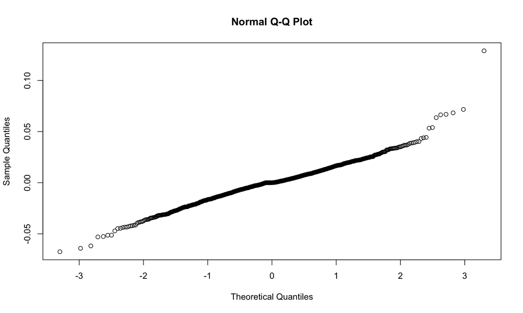

```r
# QQ-Plot der Residuen
qqnorm(residuals)
```

Das Modell spiegelt ähnliche Muster in den Autokorrelationsfunktionen (ACF und PACF) wider wie die Zeitreihe selbst. Die Residuen zeigen eine relativ gleichmäßige Verteilung, wie im Histogramm dargestellt. Allerdings zeigt der QQ-Plot, dass es bestimmte Muster oder Trends gibt, die vom Modell nicht erfasst wurden.

## Einsatzphase

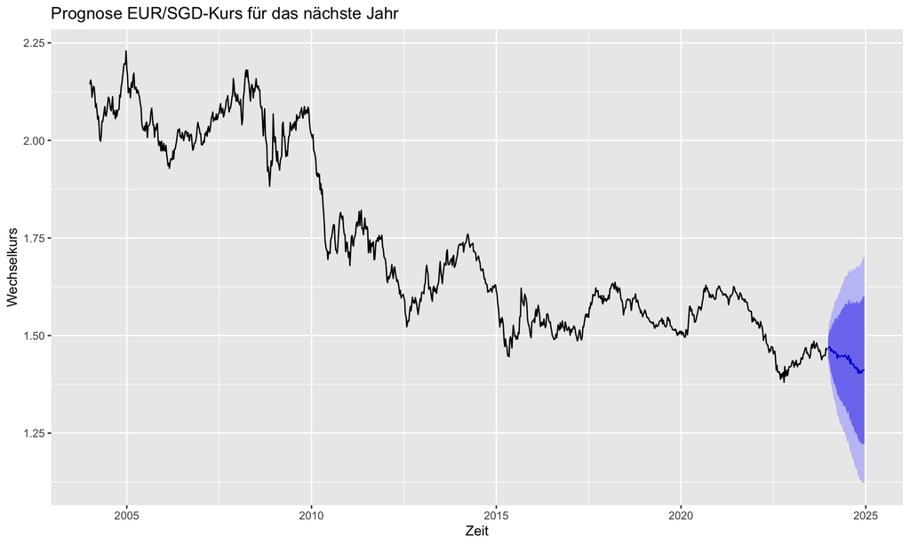

```r
# Vorhersagen generieren für 52 Wochen
forecast_sgd <- forecast(arima_model, h = 52)

# Prognose visualisieren
autoplot(forecast_sgd) +
  ggtitle("Prognose EUR/SGD-Kurs für das nächste Jahr") +
  ylab("Wechselkurs") +
  xlab("Zeit")
```

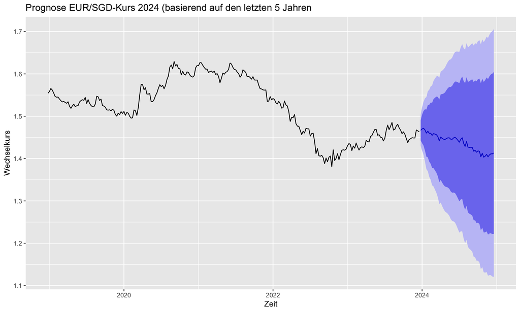

```r
# Prognose basierend auf den letzten 5 Jahren visualisieren
autoplot(forecast_sgd, include = 260) +
  ggtitle("Prognose EUR/SGD-Kurs 2024 (basierend auf den letzten 5 Jahren") +
  ylab("Wechselkurs") +
  xlab("Zeit")
```

Das erstellte ARIMA-Modell und die Identifikationsphasenanalysen deuten darauf hin, dass der Euro gegenüber dem Singapur-Dollar in Zukunft abwerten könnte, insbesondere beeinflusst durch die Finanz- und Eurokrise. Saisonalitäten im Kurs sind nicht erkennbar.

Eine mögliche Schlussfolgerung für mich könnte sein, zu Beginn des Trimesters mein Bargeld in Singapur-Dollar zu wechseln oder Studiengebühren frühzeitig zu bezahlen, um von einem günstigen Wechselkurs zu profitieren.

Es ist wichtig zu beachten, dass das Modell ausschließlich auf historischen Preisdaten basiert und ökonomische Faktoren, die den Wechselkurs stark beeinflussen, nicht berücksichtigt sind. Ereignisse wie die Finanz- und Eurokrise sind einzigartig und dürften in dieser Form nicht wiederkehren, da zukünftige Krisen andere Dynamiken aufweisen könnten.